# Nonlinear Methods: Regression & Classification Trees

## Predictive Modeling

Broadly, can organize goals as

- Unsupervised learning - goal is to learn about patterns and relationships in the data
  - No output to shoot for
- Supervised learning - a variable or variables in the data set represent an 'output' of interest
  - May wish to make **inference** on the model
  - Often just want to predict response(s)

## Supervised Learning

Commonly used supervised methods are

- Regression models
  - Least squares
  - Penalized regression
  - Locally weighted/splines
  - Generalized linear models
- Tree based methods
  - Regression/classification trees
  - Random forests, boosting, bagging

… and many more, tons of methods!

## Predictive Modeling

Where to start?

- Not going to focus on inference (applied statistics sequence covers that well!)
- Start with basic linear regression models
- Expand to different *types* of responses in the **exponential family**
- Explore tree methods
- Look at ensemble type methods to improve prediction

Lastly, we'll look at some unsupervised methods like clustering and PCA

## Regression/Classification Trees

Tree based method:

- Split up predictor space into regions, different predictions for each region

## Regression/Classification Trees

Tree based method:

- Split up predictor space into regions, different predictions for each region
- Classification tree if goal is to classify (predict) group membership
  - For a given region, usually use most prevalent class as prediction

## Regression/Classification Trees

Tree based method:

- Split up predictor space into regions, different predictions for each region
- Classification tree if goal is to classify (predict) group membership
  - For a given region, usually use most prevalent class as prediction
- Regression tree if goal is to predict a continuous response
  - For a given region, usually use mean of observations as prediction

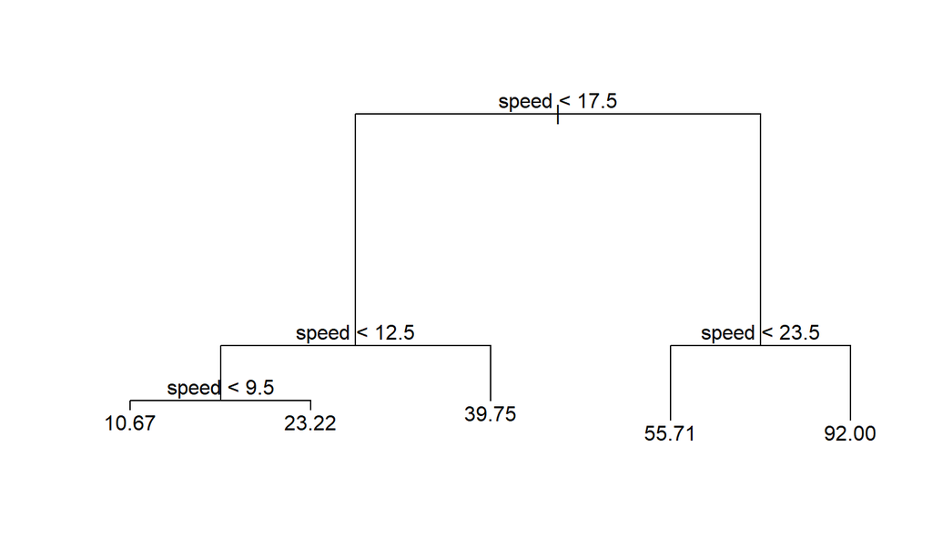

```r
library(tree) #rpart is also often used
fitTree <- tree(dist ~ speed, data = cars) #default splitting is deviance
plot(fitTree)
text(fitTree)
```

## Tree vs SLR Comparison

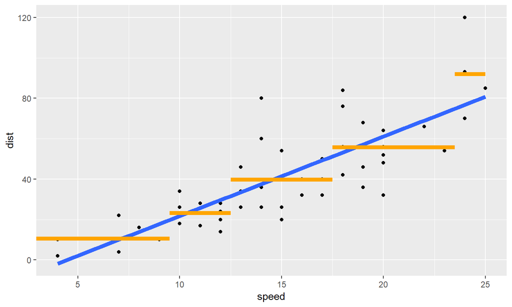

## Tree vs Polynomial Regression Comparison

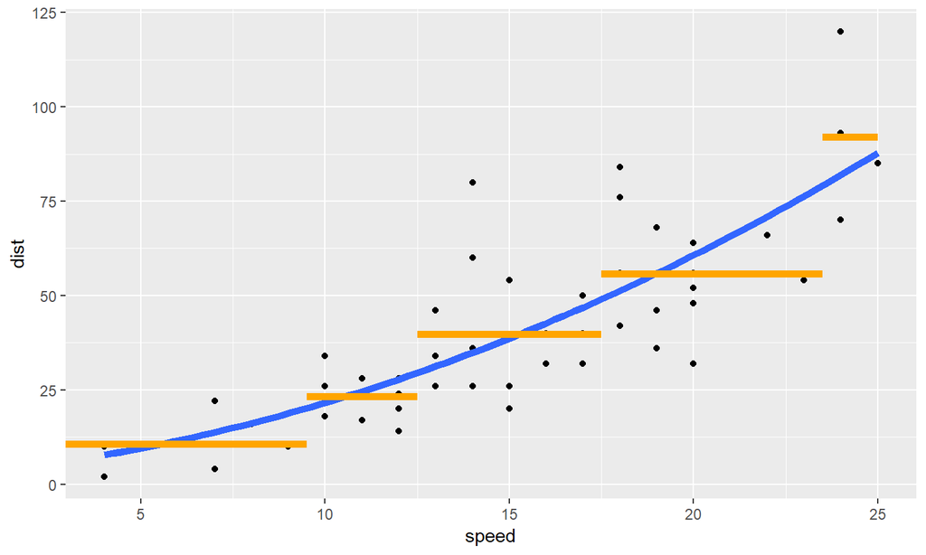

## Regression/Classification Trees

- Can still predict with `predict()`

```r
predict(fitTree, newdata = data.frame(speed = c(10, 20)))
```

```
## [1] 23.22222 55.71429
```

- Extension to more than one predictor is exactly the same idea
- Instead of fitting a plane or saddle, fit a series of flat planes (mean for a given region)

## County Level Data Set

- Consider data on voting preferences by county
  - Use pct with college degree & population change in county to predict county level income

```r
voting <- tbl_df(read.csv("../datasets/counties.csv", header = TRUE))
subVoting <- voting %>% select(college, pop.change, income)
subVoting
```

```
## # A tibble: 3,141 x 3
##   college pop.change income
##     <dbl>      <dbl>  <int>
## 1   14.5       11.9   32240
## 2   16.8       35.4   30199
## 3   11.8        2     23838
## 4    4.70       9.20  23714
## 5    7         10.6   26323
## # ... with 3,136 more rows
```

## Regression/Classification Trees

```r
treeFit <- tree(income ~ pop.change + college, data = subVoting)
treeFit
```

```
## node), split, n, deviance, yval
##       * denotes terminal node
##
##  1) root 3141 1.612e+11 28480
##    2) college < 17.55 2536 6.617e+10 26470
##      4) college < 11.65 1521 3.162e+10 24800
##        8) college < 8.05 439 7.862e+09 22780 *
##        9) college > 8.05 1082 2.124e+10 25620 *
##      5) college > 11.65 1015 2.391e+10 28980
##       10) pop.change < -2.95 379 5.086e+09 26860 *
##       11) pop.change > -2.95 636 1.612e+10 30240 *
##    3) college > 17.55 605 4.200e+10 36890
##      6) college < 24.55 381 1.557e+10 34090
##       12) pop.change < -0.95 63 1.095e+09 29340 *
##       13) pop.change > -0.95 318 1.278e+10 35030 *
##      7) college > 24.55 224 1.839e+10 41640
##       14) college < 46.5 216 1.577e+10 41000 *
##       15) college > 46.5 8 1.815e+08 58800 *
```

## Regression/Classification Trees

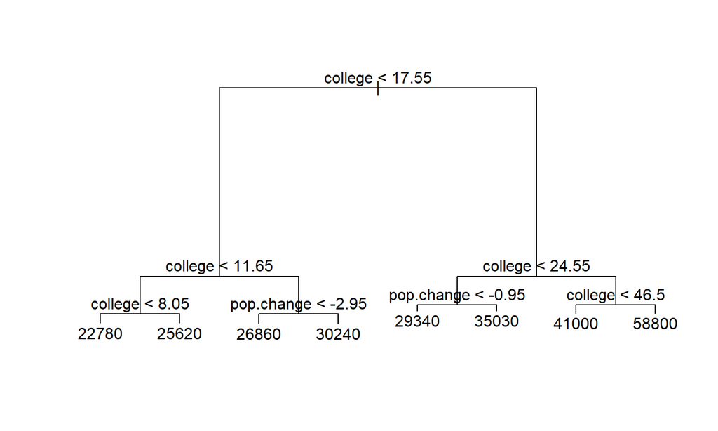

```r
plot(treeFit)
text(treeFit)
```

## Tree Visual

Trees automatically account for interactions

```r
#set up prediction explanatory variables
grid.lines = 60
x.pred <- seq(min(subVoting$pop.change), max(subVoting$pop.change), length.out = grid.lines)
y.pred <- seq(min(subVoting$college), max(subVoting$college), length.out = grid.lines)
xy <- expand.grid(pop.change = x.pred, college = y.pred)
#predictions
z.tree.pred <- matrix(predict(treeFit, newdata = xy),
                                 nrow = grid.lines, ncol = grid.lines)
# scatter plot with regression plane (rgl package)
plot3d(x = subVoting$pop.change, y = subVoting$college, z = subVoting$income,
                    cex = 0.8, theta = 20, phi = 20, ticktype = "detailed",
                    xlab = "Pop Change", ylab = "Per College", zlab =
"Income")
#add surfaces
surface3d(x = x.pred, y = y.pred, z = z.tree.pred, color = "blue")
```

## Tree Visual

[interactive chart not shown]

You must enable Javascript to view this page properly.

## Comparison of Tree with MLR

[interactive chart not shown]

You must enable Javascript to view this page properly.

## Including a Categorical Predictor

- May want fits that differ by the level of a variable

```r
treeFit <- tree(income ~ college + region, data = voting)
treeFit
```

```
## node), split, n, deviance, yval
##       * denotes terminal node
##
##  1) root 3141 1.612e+11 28480
##    2) college < 17.55 2536 6.617e+10 26470
##      4) college < 11.65 1521 3.162e+10 24800
##        8) region: South 879 1.560e+10 23590 *
##        9) region: Midwest,Northeast,West 642 1.300e+10 26440 *
##      5) college > 11.65 1015 2.391e+10 28980 *
##    3) college > 17.55 605 4.200e+10 36890
##      6) college < 24.55 381 1.557e+10 34090 *
##      7) college > 24.55 224 1.839e+10 41640
##       14) college < 46.5 216 1.577e+10 41000
##         28) region: Midwest,South,West 168 9.885e+09 39130 *
##         29) region: Northeast 48 3.235e+09 47550 *
##       15) college > 46.5 8 1.815e+08 58800 *
```

## Including a Categorical Predictor

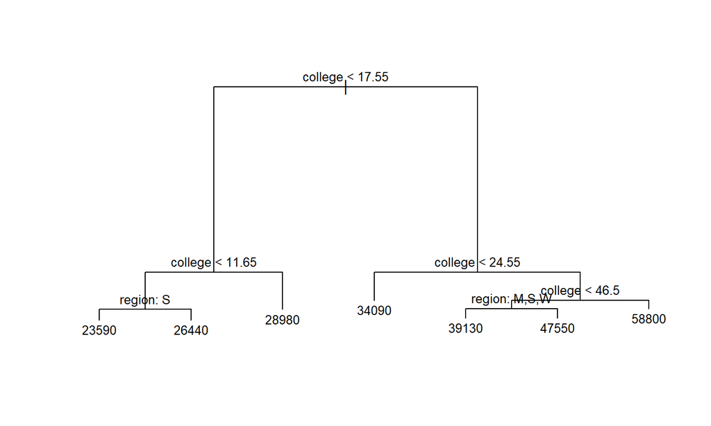

```r
plot(treeFit)
text(treeFit, pretty = 1, cex = 0.8)
```

## Regression/Classification Trees

Tree based method:

- Split up predictor space into regions, different predictions for each region
- Classification tree if goal is to classify (predict) group membership
  - For a given region, usually use most prevalent class as prediction
- Regression tree if goal is to predict a continuous response
  - For a given region, usually use mean of observations as prediction

## Classification Tree

- Consider the FG data set

```r
FGData <- read_sas("..\\datasets\\FG.sas7bdat")
FGData$outcome <- as.factor(FGData$outcome)
FGData
```

```
## # A tibble: 17,104 x 8
##   gameid       kicker       outcome yards  year fgpct fgstrg  good
##   <chr>        <chr>        <fct>   <dbl> <dbl> <dbl> <chr>  <dbl>
## 1 200309070gnb Aaron Elling good       22  2003 0.679 19/28      1
## 2 200309070gnb Aaron Elling good       46  2003 0.679 19/28      1
## 3 200309070gnb Aaron Elling good       34  2003 0.679 19/28      1
## 4 200309140min Aaron Elling good       23  2003 0.679 19/28      1
## 5 200309140min Aaron Elling no good    53  2003 0.679 19/28      0
## # ... with 1.71e+04 more rows
```

## Classification Tree

- Break up region by yards and give prediction
- Prediction = most common outcome in class

```r
FGTreeFit <- tree(outcome ~ yards, data = FGData, split = "deviance")
FGTreeFit
```

```
## node), split, n, deviance, yval, (yprob)
##       * denotes terminal node
##
## 1) root 17104 16510 good ( 0.81244 0.18756 )
##   2) yards < 36.5 8365  4414 good ( 0.92600 0.07400 )
##     4) yards < 27.5 3938  1053 good ( 0.97029 0.02971 ) *
##     5) yards > 27.5 4427  3130 good ( 0.88660 0.11340 ) *
##   3) yards > 36.5 8739 10620 good ( 0.70374 0.29626 )
##     6) yards < 47.5 5873  6467 good ( 0.76043 0.23957 ) *
##     7) yards > 47.5 2866  3885 good ( 0.58758 0.41242 ) *
```

Misclassification rate important measure of how good the tree is!

This is on the training set though…

```r
summary(FGTreeFit)
```

```
##
## Classification tree:
## tree(formula = outcome ~ yards, data = FGData, split = "deviance")
## Number of terminal nodes:  4
## Residual mean deviance:  0.85 = 14540 / 17100
## Misclassification error rate: 0.1876 = 3208 / 17104
```

## Classification Tree

Classify all as good! (all classes have at least 50% made)

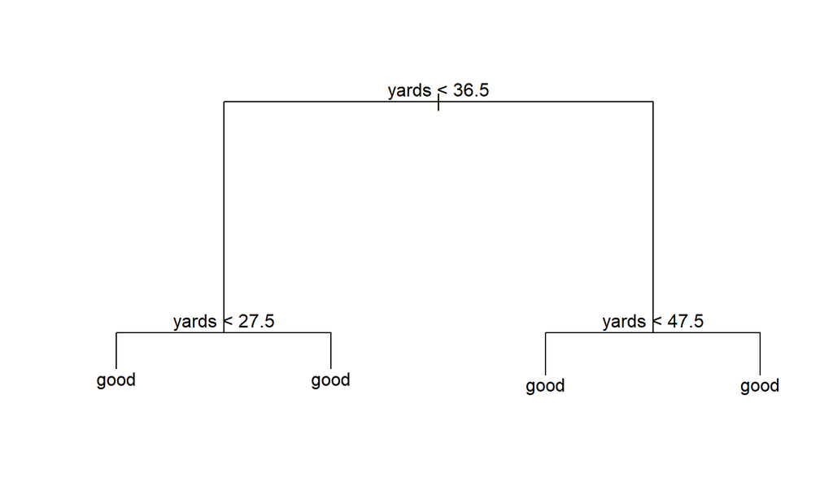

```r
plot(FGTreeFit)
text(FGTreeFit)
```

## Visual of Proportion in Each Class

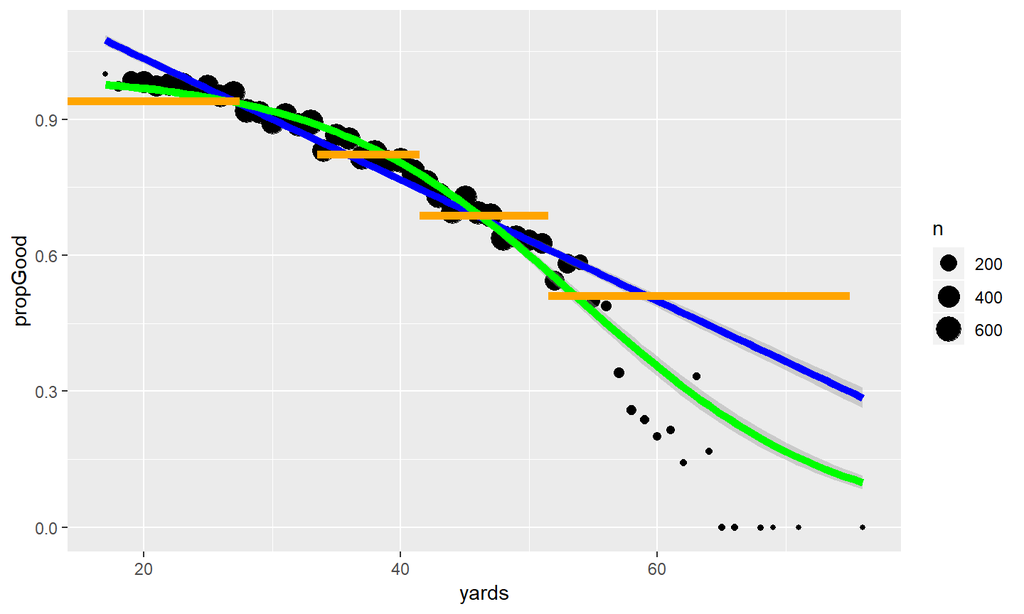

## Classification Tree

Prediction with `predict()`

- Can get probability predictions. Not great with this method but a reasonable start

```r
predict(FGTreeFit, newdata = data.frame(yards = c(25, 40, 50)))
```

```
##        good    no good
## 1 0.9702895 0.02971051
## 2 0.7604291 0.23957092
## 3 0.5875785 0.41242149
```

- Just predict the class

```r
predict(FGTreeFit, type = "class", newdata = data.frame(yards = c(25, 40, 50, 60)))
```

```
## [1] good good good good
## Levels: good no good
```